# Exploratory Data Analysis - Project 3

Team Gryffindor

3/21/2022

```r
library(tidyverse)
library(scales)
library(RColorBrewer)
library(ggrepel)
library(usmap)
library(lubridate)
library(reshape2)
library(curl)
library(rvest)
```

## Exploratory Data Analysis - Project 3

This document will perform exploratory data analysis on a loan dataset from Kaggle entitled the [LendingClub.](https://www.kaggle.com/datasets/wordsforthewise/lending-club)

**Questions are as follows:**

*What are the most common:*

- Job Titles
- Loan purpose request
- States with loan request

*Does loan grade or loan status have anything to do with job title?*

*Does FICO score effect interest rate?*

*How do loan amounts relate to salaries?*

### Import data

[Kaggle LendingClub](https://www.kaggle.com/wordsforthewise/lending-club?select=accepted_2007_to_2018Q4.csv.gz) data set was modified by extrapolating all data prior to 2018, and imported form MySQLWorkbench into R.

```r
url <- "http://data607project3.com/list-all.php"
data_html <- read_html(url)
loan_df <- html_table(data_html, fill = T)[[1]]

# preview df
glimpse(loan_df)
```

```
## Rows: 686
## Columns: 63
## $ id                          <int> 1, 2, 3, 4, 5, 6, 7, 8, 9, 10, 11, 12, 13,…
## $ loan_amnt                   <int> 5000, 15000, 11200, 25000, 3000, 17000, 20…
## $ funded_amnt                 <int> 5000, 15000, 11200, 25000, 3000, 17000, 20…
## $ term                        <chr> "36 months", "36 months", "60 months", "60…
## $ int_rate                    <dbl> 20.39, 9.92, 30.79, 21.85, 7.34, 20.39, 10…
## $ installment                 <dbl> 186.82, 483.45, 367.82, 688.35, 93.10, 454…
## $ grade                       <chr> "D", "B", "G", "D", "A", "D", "B", "D", "A…
## $ emp_title                   <chr> "General Manager", "IT Director", "Client …
## $ emp_length                  <chr> "8 years", "2 years", "< 1 year", "10+ yea…
## $ home_ownership              <chr> "RENT", "OWN", "RENT", "MORTGAGE", "RENT",…
## $ issue_d                     <chr> "18-Mar", "18-Mar", "18-Mar", "18-Mar", "1…
## $ annual_inc                  <int> 50000, 196000, 44000, 65000, 52000, 52000,…
## $ verification_status         <chr> "Verified", "Source Verified", "Not Verifi…
```

[output cut: 50 more lines]

Data has 63 columns and 686 rows.

[Data Dictionary](https://www.kaggle.com/jonchan2003/lending-club-data-dictionary) can be referenced to specify column meanings.

### Job type

Let’s look at the `emp_title` column to see what types of jobs folks had.

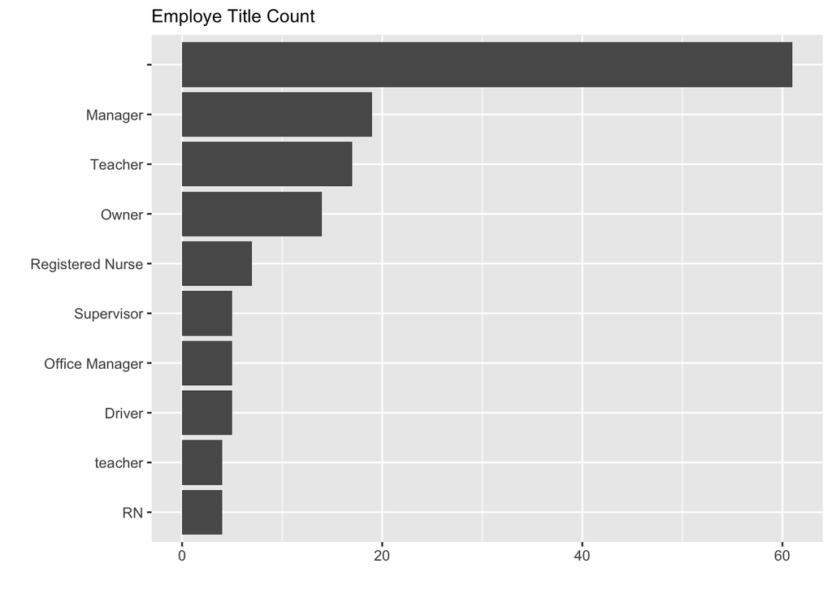

```r
emp_count <- loan_df %>%
  count(emp_title) %>%
  arrange(desc(n)) %>%
  slice_max(n, n = 10) %>%
  ggplot(aes(reorder(emp_title, n),n)) +
    geom_bar(stat = "identity") +
    coord_flip() +
    scale_fill_gradient2(high = muted("blue")) +
    labs(x="", y="", subtitle = "Employe Title Count")

ggsave("../images/emp_title_count.png",
       plot = emp_count)

emp_count
```

Some titles are the same, just have different cases and perhaps some white space. Let’s clean this up.

```r
loan_df <- loan_df %>%
  mutate(emp_title = trimws(tolower(emp_title)))
```

Let’s try the count again chart again, this time with color.

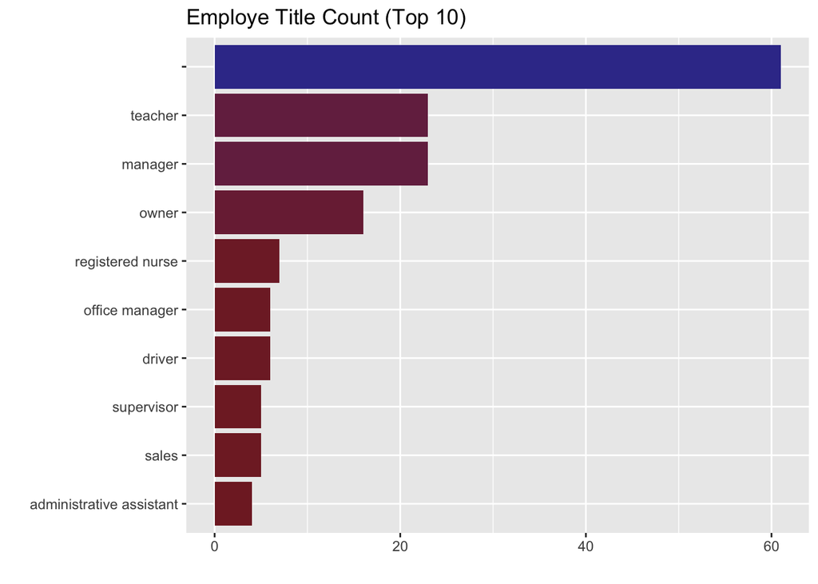

```r
emp_count_col <- loan_df %>%
  count(emp_title) %>%
  arrange(desc(n)) %>%
  slice_max(n, n = 10, with_ties = F) %>%
  ggplot(aes(reorder(emp_title, n),n, fill = n)) +
    geom_bar(stat = "identity") +
    coord_flip() +
    scale_fill_gradient2(high = muted("blue"), mid = muted("red")) +
    labs(x="", y="", title = "Employe Title Count (Top 10)") +
    theme(legend.position = "none")

ggsave("../images/emp_title_count_col.png", plot = emp_count_col)
emp_count_col
```

If we filter out NA let’s see this now:

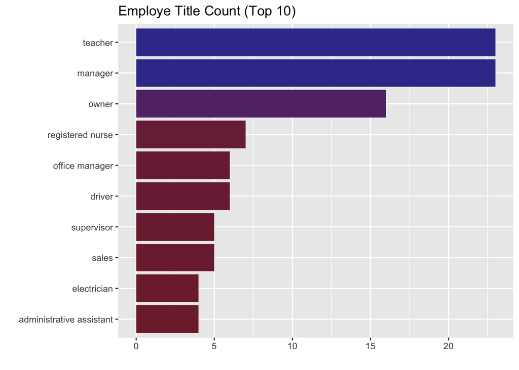

```r
emp_count_col_na <- loan_df %>%
  filter(emp_title != "") %>%
  count(emp_title) %>%
  arrange(desc(n)) %>%
  slice_max(n, n = 10, with_ties = F) %>%
  ggplot(aes(reorder(emp_title, n),n, fill = n)) +
    geom_bar(stat = "identity") +
    coord_flip() +
    scale_fill_gradient2(high = muted("blue"), mid = muted("red")) +
    labs(x="", y="", title = "Employe Title Count (Top 10)") +
    theme(legend.position = "none")

ggsave("../images/emp_title_count_col_nona.png", plot = emp_count_col_na)
emp_count_col_na
```

Let’s look at that as a percentage:

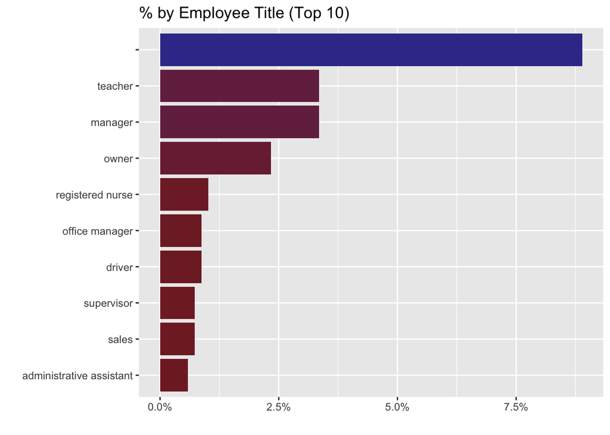

```r
emp_count_col_per <- loan_df %>%
  count(emp_title) %>%
  mutate(p = n/sum(n)) %>%
  slice_max(n, n = 10, with_ties = F) %>%
  ggplot(aes(reorder(emp_title, n),p, fill = p)) +
    geom_bar(stat = "identity") +
    coord_flip() +
    scale_fill_gradient2(high = muted("blue"), mid = muted("red")) +
    labs(x="", y="", title = "% by Employee Title (Top 10)") +
    scale_y_continuous(labels = percent) +
    theme(legend.position = "none")

ggsave("../images/emp_title_col_per_nona.png", emp_count_col_per)
emp_count_col_per
```

So highest proportion of job titles reported by percentage are:

- `teacher` with ~3.5%
- `manager` with ~3.5%
- `owner` with ~2.4%

### Loan Purpose

LendingClub notates the purpose of each loan. Let’s see what the most common loan purpose.

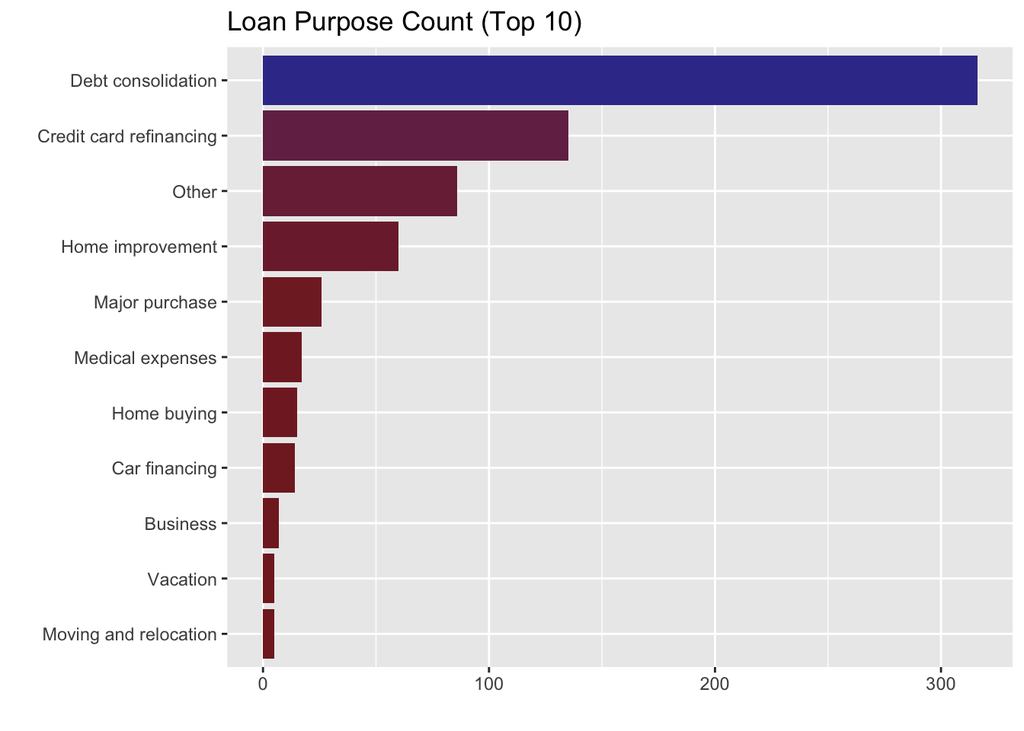

```r
pur_count <- loan_df %>%
  group_by(title) %>%
  filter(title != "") %>%
  summarise(count = n()) %>%
  top_n(n = 10, wt = count) %>%
  ggplot(aes(x = reorder(title,count), y = count, fill = count)) +
    geom_bar(stat = "identity") +
    scale_fill_gradient2(high = muted("Blue"), mid = muted("red")) +
    labs(title = "Loan Purpose Count (Top 10)", x="",y="") +
    coord_flip() +
    theme(legend.position = "none")

ggsave("../images/loan_pur_count.png", plot = pur_count)
pur_count
```

We can see `Debt consolidation` is by far the highest reason for loan purpose.  
This is followed by `Credit card refinancing` and `Other`.

Let’s look at this as a proportion.

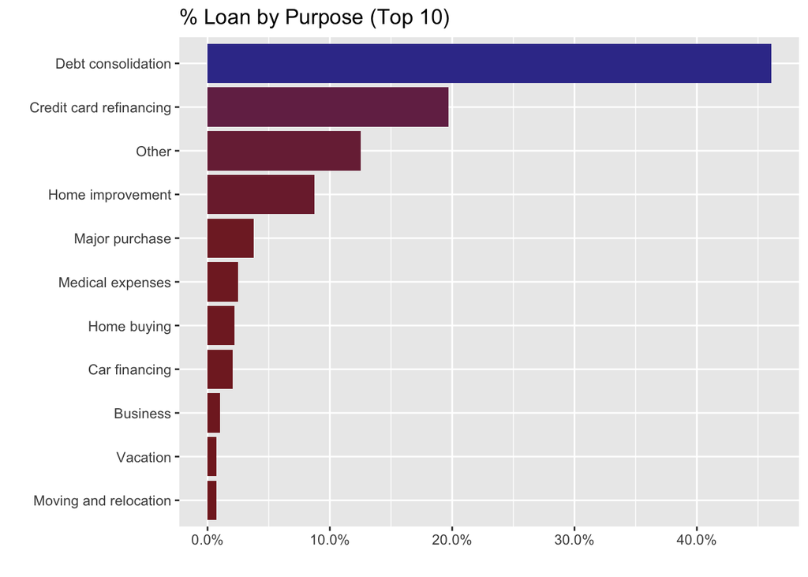

```r
pur_per <- loan_df %>%
  filter(title != "") %>%
  count(title) %>%
  mutate(p = n/sum(n)) %>%
  slice_max(p, n = 10) %>%
  ggplot(aes(x = reorder(title, p), y = p, fill = p)) +
    geom_bar(stat = "identity") +
    coord_flip() +
    scale_fill_gradient2(high = muted("blue"), mid = muted("red")) +
    labs(title = "% Loan by Purpose (Top 10)", x = "", y = "") +
    scale_y_continuous(labels = percent) +
    theme(legend.position = "none")

ggsave("../images/loan_pur_per.png", plot = pur_per)
pur_per
```

### Grade

LendingClub assigns a grade for each loan, let’s look at the different grades and then sort it with `emp_title`.

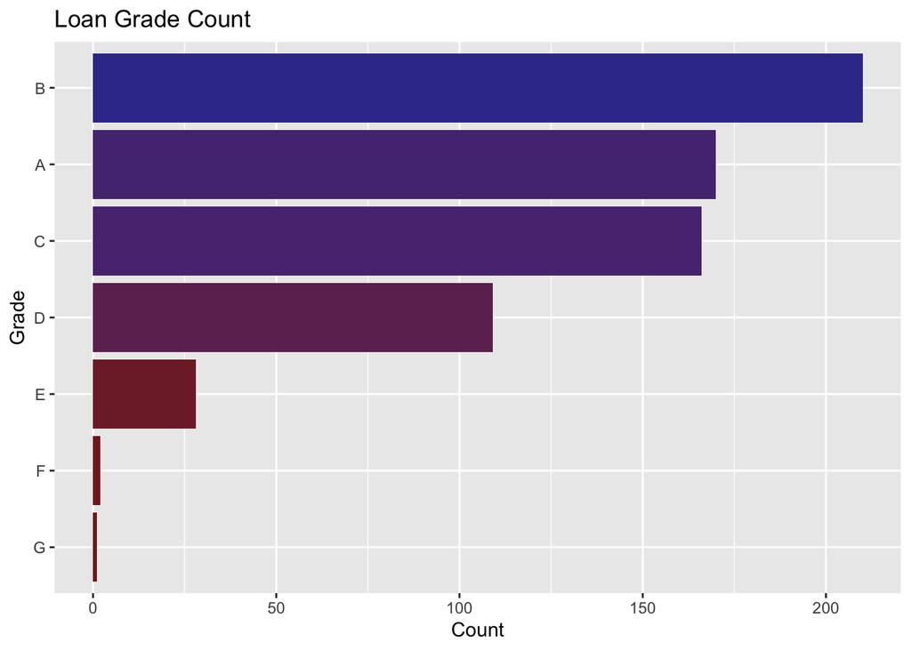

```r
grade_count <- loan_df %>%
  count(grade) %>%
  ggplot(aes(reorder(grade,n), n, fill = n)) +
    geom_bar(stat = "identity") +
    scale_fill_gradient2(high = muted("blue"), mid = muted("red")) +
    coord_flip() +
    labs(x = "Grade", y = "Count", title = "Loan Grade Count") +
    theme(legend.position = "none")

ggsave("../images/loan_grade_count.png", grade_count)
grade_count
```

Grade by proportion.

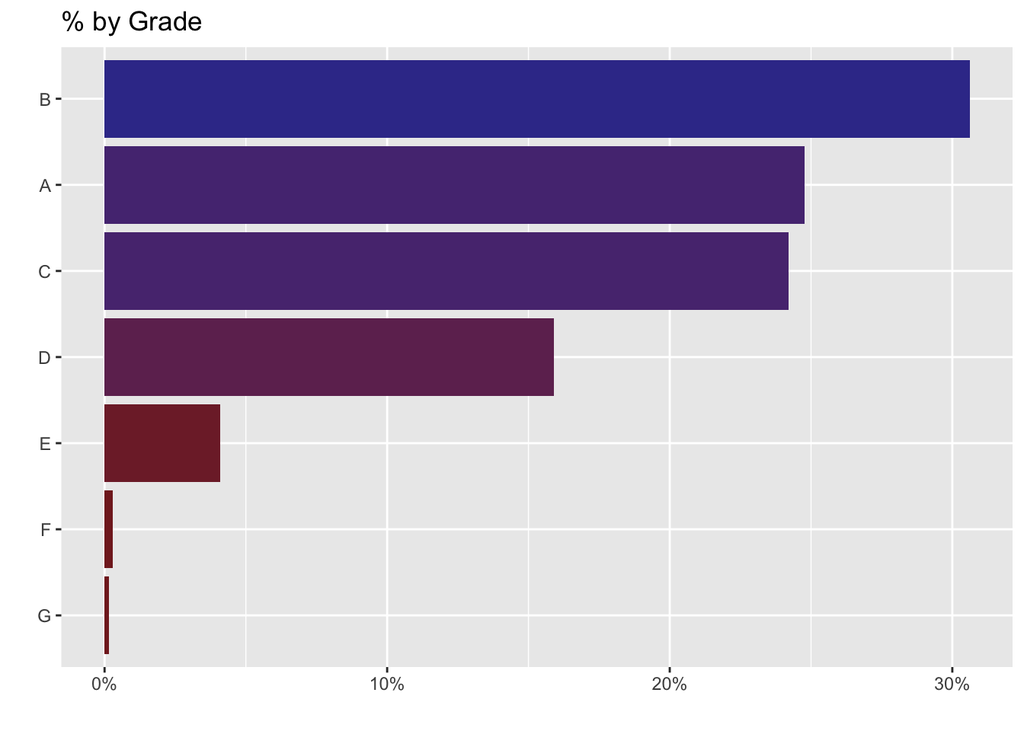

```r
grade_per <- loan_df %>%
  count(grade) %>%
  mutate(p = n/sum(n)) %>%
  ggplot(aes(reorder(grade, n),p, fill = p)) +
    geom_bar(stat = "identity") +
    coord_flip() +
    scale_fill_gradient2(high = muted("blue"), mid = muted("red")) +
    labs(x="", y="", title = "% by Grade") +
    scale_y_continuous(labels = percent) +
    theme(legend.position = "none")

ggsave("../images/loan_grade_per.png", grade_per)
grade_per
```

`B` is the most frequent `grade`, and makes up about 30% of loans.

Let’s look at how this relates to `emp_title`.

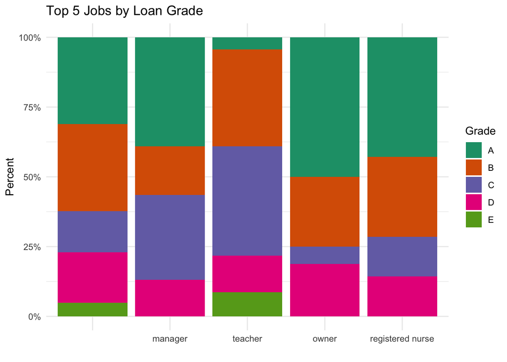

```r
# create df for top 5 emp title
top_5_emp_title <- loan_df %>%
  count(emp_title) %>%
  filter(!is.na(emp_title)) %>%
  arrange(desc(n)) %>%
  head(5)

# compare emp title by grade
top_5_loan_grade <- loan_df %>%
  filter(emp_title%in%top_5_emp_title$emp_title) %>% # filter top5 emp
  group_by(emp_title, grade) %>%
  summarise(
    count = n()
  ) %>%
  ggplot(aes(x = factor(emp_title,
      levels = as.vector(top_5_emp_title$emp_title)),
      y = count,
      fill = grade)) +
    geom_bar(stat = "identity", position = "fill") +
    scale_fill_brewer(palette = "Dark2") +
    labs(x = "", y = "Percent", title = "Top 5 Jobs by Loan Grade") +
    scale_y_continuous(labels = percent) +
    guides(fill=guide_legend(title = "Grade")) +
    theme_minimal()
ggsave("../images/top_5_jobs_grade.png", plot = top_5_loan_grade)
top_5_loan_grade
```

So we can see that of the top 5 jobs, `owner` has the largest proportion of A loans, whilst `teacher` C and E.  
So perhaps this suggest owner’s have better graded loans then teachers.

### Loan status

Let’s look distribution of loan status.

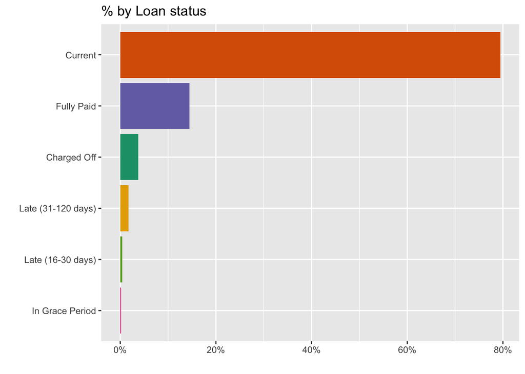

```r
status <- loan_df %>%
  count(loan_status) %>%
  mutate(p = n / sum(n)) %>%
  ggplot(aes(reorder(loan_status, p), p, fill = loan_status)) +
    geom_bar(stat = "identity") +
    coord_flip() +
    labs(x = "", y = "", title = "% by Loan status") +
    scale_y_continuous(labels = percent) +
    theme(legend.position = "none") +
    scale_fill_brewer(palette = "Dark2")

ggsave("../images/loan_status.png", plot = status)
status
```

```r
loan_df %>%
  filter(loan_status == "Late (31-120 days)" |
           loan_status == "Late (16-30 days") %>%
  group_by(emp_title) %>%
  summarise(
    count = n()
  ) %>%
  arrange(desc(count)) %>%
  head(10)
```

```
## # A tibble: 10 × 2
##    emp_title                  count
##    <chr>                      <int>
##  1 ""                             1
##  2 "administrative assistant"     1
##  3 "associate auditor"            1
##  4 "commercial airline pilot"     1
##  5 "database administrator"       1
##  6 "lead man"                     1
##  7 "maintenance engineer"         1
##  8 "manager"                      1
##  9 "paralegal"                    1
## 10 "security guard"               1
```

So late loan payments seem to be an anomaly and no real pattern in regard to ``emp_title`.

### Does FICO score effect interest rate?

We expect that it would, but let’s confirm.

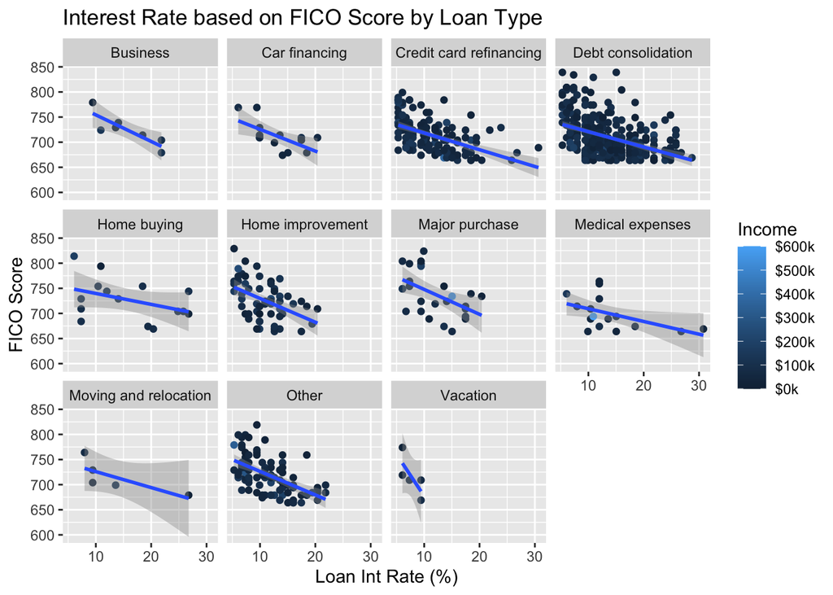

```r
credit_intrate <-loan_df %>%
  ggplot(aes(x=int_rate, y=fico_range_high,col=annual_inc)) +
  geom_point() +
    geom_smooth(method=lm) +
    labs(title = "Interest Rate based on FICO Score by Loan Type", x="Loan Int Rate (%)",y="FICO Score",colour="Annual Income") +
  scale_colour_continuous(name = "Income",
                          label = dollar_format(prefix = "$",
                                                scale = .001,
                                                suffix = "k")) +
    facet_wrap(~title)

ggsave("../images/fico_interest.png", plot = credit_intrate)
credit_intrate
```

We can clearly see a negative relationship with FICO score and interest rate. If you have a higher credit score your interest rate goes down. Seems counter intuitive no? That’s capitalism for ya!

### Loan attributes by State

What are the most common states where loan applications are submitted?

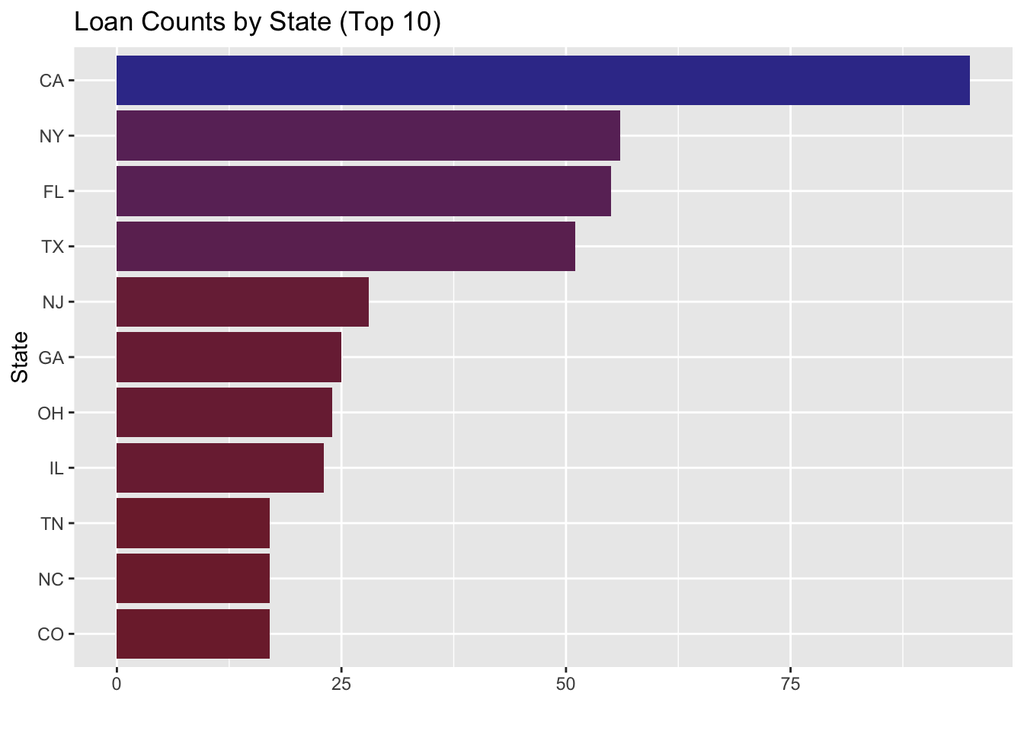

```r
app_state <- loan_df %>%
  group_by(addr_state) %>%
  filter(addr_state != "") %>%
  summarise(count = n()) %>%
  top_n(n = 10, wt = count) %>%
  ggplot(aes(x = reorder(addr_state,count), y = count, fill = count)) +
    geom_bar(stat = "identity") +
    scale_fill_gradient2(high = muted("Blue"), mid = muted("Red")) +
    labs(title = "Loan Counts by State (Top 10)", x="State",y="") +
    coord_flip() +
    theme(legend.position = "none")

ggsave("../images/state_loan_count.png", plot = app_state)
app_state
```

We can see `CA` has the highest count, followed by `NY` and `FL`.  
Let’s take a look at this on a map.

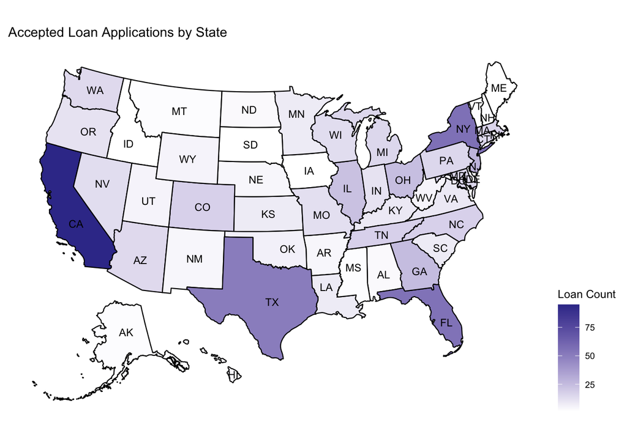

```r
# read in states csv
states<-read.csv(curl("https://raw.githubusercontent.com/brsingh7/DATA607/main/states.csv"))

# merge with loans df
loans_bs3 <- merge(loan_df,states,by.x=c("addr_state"),by.y=c("Code"),all.y=T)


state_counts <- loans_bs3 %>%
  group_by(State) %>%
  summarise(count=n(), avg_loan=mean(loan_amnt))
  state_counts$fips <- fips(state_counts$State)

  apps <- plot_usmap(data = state_counts,
                     values = "count",
                     color = "black", labels=TRUE) +
  scale_fill_continuous(low = "white",
                        high = muted("blue"),
                        name = "Loan Count",
                        label = comma) +
  labs(title="Accepted Loan Applications by State") +
  theme(legend.position = "right")

apps$layers[[2]]$aes_params$size <- 3

ggsave("../images/state_loan_acc_map.png", plot = apps)
apps
```

Well that’s interesting, but perhaps pure counts isn’t the best way to look at it, let’s look at average loan amount per state.

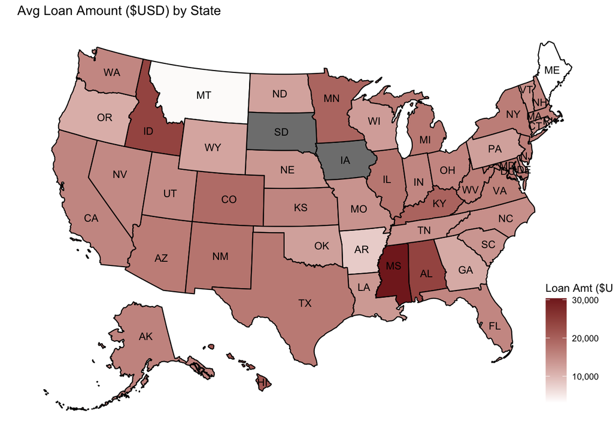

```r
avg_state <- plot_usmap(data = state_counts,
                        values = "avg_loan",
                        color = "black", labels=TRUE) +
  scale_fill_continuous(low = "white",
                        high = muted("red"),
                        name = "Loan Amt ($USD)",
                        label = comma) +
  labs(title="Avg Loan Amount ($USD) by State") +
  theme(legend.position = c(0.9,0.05))

avg_state$layers[[2]]$aes_params$size <- 3

ggsave("../images/state_avg_loan.png", avg_state)
avg_state
```

So now we can see the states with the highest average loan amount are:

Interesting, well now let’s get some income data from [Wikipedia](https://en.wikipedia.org/wiki/List_of_U.S._states_and_territories_by_income) , and look at loan amounts vs. salary.

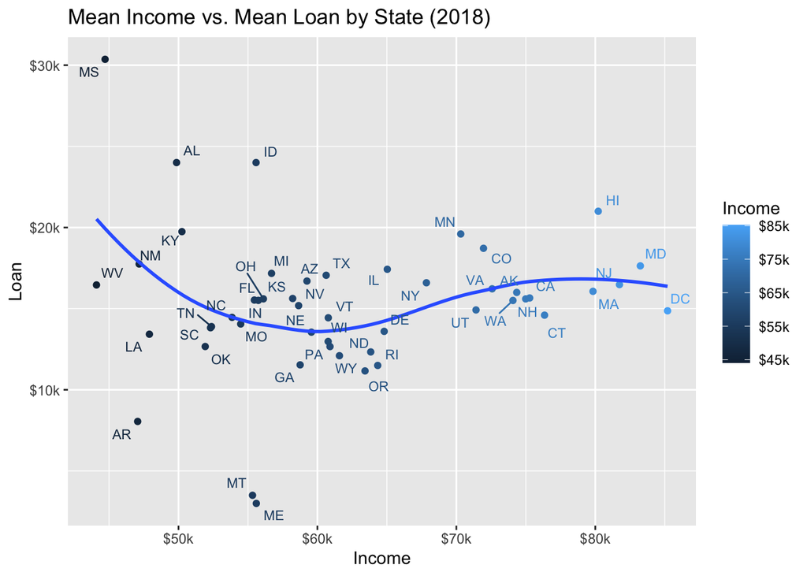

```r
# read in income data
income_2018<-read.csv(curl("https://raw.githubusercontent.com/brsingh7/DATA607/main/Project3/income_2018.csv"))

# group by state avg loan
loans_2018<- loans_bs3 %>%
  group_by(addr_state) %>%
  summarise(avg_ln=mean(funded_amnt))

# join with salary data
loan_v_salary <- left_join(loans_2018,income_2018,by=c("addr_state"="Code"))

# scatterplot
loan_v_salary_plot <- loan_v_salary %>%
  ggplot(aes(x = avg_inc_2018, y = avg_ln, color = avg_inc_2018)) +
  geom_point() +
  geom_smooth(se=F) +
  labs(title = "Mean Income vs. Mean Loan by State (2018)",
       x="Income",y="Loan") +
  geom_text_repel(aes(label = addr_state), size = 3) +
  scale_y_continuous(label = dollar_format(prefix = "$",
                                           scale = .001,
                                           suffix = "k")) +
  scale_x_continuous(label = dollar_format(prefix = "$",
                                           scale = .001,
                                           suffix = "k")) +
  scale_colour_continuous(name = "Income",
                          label = dollar_format(prefix = "$",
                                                scale = .001,
                                                suffix = "k")) +
  theme(legend.position = "right")

ggsave("../images/loan_vs_sal.png")

loan_v_salary_plot
```

We can see there is not exactly a linear relationship between average loan amount per state and average income. However we can see `Mississippi (MS)` which from the previous map we could see had the highest average loan amount, also has one of the lowest incomes.  
Whereas states that had the highest counts of loans like `California` and `New York` had lower average loan amounts and much higher average incomes.

## Conclusion

Next steps would be to merge demographic data from the census api to conduct an analysis of how this all relates to different aspects such as income, race, sex and more focused geographical boundaries.